# MASLD Treatment Model Guidance: Running on Posit Cloud

Author

[Andy Wilson](https://github.com/ASW-Analyst/)  
[NHS Transformation Unit](https://transformationunit.nhs.uk/)

Published

27 February 2025

# 1 Introduction

The purpose of this document is to provide guidance on how to run the model using [Posit Cloud](https://posit.cloud/). **Posit Cloud** enables you to access Posit’s data science tools such as RStudio within your browser. This negates the requirements to install software such as R, RStudio and Git onto your own device. Please follow the instructions below that demonstrate how to run the model.

# 2 Logging into Posit Cloud

1. Open your web browser and go to the [Posit Cloud Login](https://login.posit.cloud/login?redirect=%2Foauth%2Fauthorize%3Fredirect_uri%3Dhttps%253A%252F%252Fposit.cloud%252Flogin%26client_id%3Dposit-cloud%26response_type%3Dcode%26show_auth%3D0&product=cloud).

[figure not shown]

Posit Cloud Login

2. Enter your credentials or sign-up if you don’t have an account. I would recommend **Login with GitHub** if you already have a GitHub account. Signing up for Posit Cloud or GitHub is entirely free.

# 3 Setting-up the Project

1. Once logged in click on the **New Project** button in the top-right of the screen.
2. Then select **New Project from Git Repository**.

[figure not shown]

New Project

3. This will open up a box asking for the URL of the GitHub repository. Please enter: `https://github.com/NHS-Transformation-Unit/masld_treatments_model`

[figure not shown]

New Project URL

4. The project will then set-up the repository within RStudio.

[figure not shown]

Project Loaded

# 4 Loading Dependencies

The model has been written in the statistical programming language R. To run the model it is necessary to install the R packages that the model depends on. This should only be required the first time you create the project on Posit Cloud.

1. The bottom right quadrant of the screen will show a file explorer tab. Navigate to the file `src/requirements/packages.R`. When you click on the file this will open in a new window in the top left.

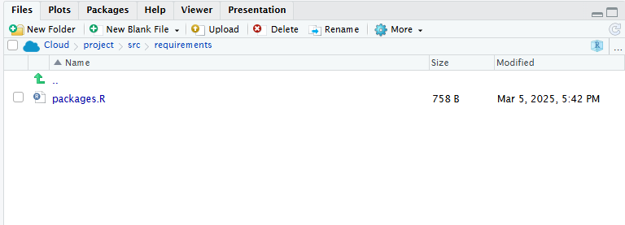

Navigating to packages.R

[figure not shown]

Opening packages.R

2. This file contains a list of the required packages and the code to install these. To run the script either:
   - Select all the code and type `Ctrl` + `Enter`
   - Or alternatively, click on the **Source** button.
3. In the **Console** screen in the bottom left you will see the program installing the required dependencies. This will be complete once the red **STOP** button has disappeared.

[figure not shown]

Installing Packages

# 5 Running the Model

1. Now in the file explorer navigate back to `project`.
2. There is a file called `run_app.R`. Click on this file to open it up in a new window in the top left.

[figure not shown]

Open `run_app.R`

3. You will see a button **Run App** with a green triangle. Click this to run the app.

4. After a few seconds the app will load up in a new window.
5. You can use the app within this window or click **Open in Browser** to launch within a browser window if preferred.

[figure not shown]

Running App Window